# Cyclistic_Analysis_2021

Yash

21/01/2022

## Calling In Required packages

For performing various cleaning , analising and visualizing tasks we need to load some basic or advanced packages.

```r
library(tidyverse)
library(lubridate)
library(janitor)
library("dplyr")
rm(list=ls())  ##for clearing environment page
```

## Importing Files and Preparing Data

This section shows the process of importing data and preparing it for further cleaning and analysis.

```r
t1 <- read.csv("202101-divvy-tripdata.csv")
t2 <- read.csv("202102-divvy-tripdata.csv")
t3 <- read.csv("202103-divvy-tripdata.csv")
t4 <- read.csv("202104-divvy-tripdata.csv")
t5 <- read.csv("202105-divvy-tripdata.csv")
t6 <- read.csv("202106-divvy-tripdata.csv")
t7 <- read.csv("202107-divvy-tripdata.csv")
t8 <- read.csv("202108-divvy-tripdata.csv")
t9 <- read.csv("202109-divvy-tripdata.csv")
t10 <- read.csv("202110-divvy-tripdata.csv")
t11 <- read.csv("202111-divvy-tripdata.csv")
```

### Preparing Data

Now we will prepare data by creating some new required fields and changing some datatypes (if required),also some required cleaning will also be carried out at this stage so that we face least amount of resistance while analysing our required trend or anything related to our main goal.

```r
bike_data <- rbind(t1,t2,t3,t4,t5,t6,t7,t8,t9,t10,t11)
```

```r
bike_data <- remove_empty(bike_data,which = c("rows","cols"))
bike_data$start_station_name[bike_data$start_station_name == ""]<- NA
bike_data <- bike_data %>%
  drop_na()
```

```r
bike_data$dates <- as.Date(bike_data$started_at)
bike_data$started_at <- ymd_hms(bike_data$started_at)
bike_data$ended_at <- ymd_hms(bike_data$ended_at)
```

```r
bike_data$start_hour <- hour(bike_data$started_at)
bike_data$end_hour <- hour(bike_data$ended_at)
bike_data$duration <- (bike_data$ended_at)-(bike_data$started_at)
bike_data$duration_hours <- difftime(bike_data$ended_at,bike_data$started_at,units = c("hours"))
bike_data$duration_mins <- difftime(bike_data$ended_at,bike_data$started_at,units = c("mins"))
```

```r
bike_data <-bike_data %>%
  filter(duration > 0)

bike_data_prepared <- bike_data %>% select(dates,rideable_type,started_at,ended_at,start_station_name,member_casual,start_hour,end_hour,duration_hours,duration_mins,duration)
```

## Analysis

Our task is to identify the trend or any sort of useful insight that help to improve to adoption our wider range of customers, for which we are going to study the numbers between the two different type of customers that Cyclistic company deals with one those are members and other casual ones.

```r
bike_data %>%
  group_by(member_casual) %>%
  summarise(Count=n())
```

```
## # A tibble: 2 x 2
##   member_casual   Count
##   <chr>           <int>
## 1 casual        2154712
## 2 member        2547831
```

```r
aggregate(bike_data$duration ~ bike_data$member_casual , FUN = mean)
```

```
##   bike_data$member_casual bike_data$duration
## 1                  casual     1925.0335 secs
## 2                  member      812.1366 secs
```

```r
Weekly_ride_data <- bike_data %>%
  mutate(Weekday = wday(bike_data$started_at,label = TRUE)) %>%
  group_by(member_casual,Weekday) %>%
  summarise(Count=n(),
            average_ride_length = mean(duration)) %>%
  arrange(member_casual,Weekday)
hourly_ride_data <- bike_data %>%
  group_by(Weekly = floor_date(dates,"week"),start_hour,member_casual) %>%
  summarise(total_mins = sum(duration_mins),
            Mean = mean(duration_mins),
            Median = median(duration_mins),
            Max = max(duration_mins),
            Min = min(duration_mins),
            Count = n())
monthly_ride_data <- bike_data %>%
  mutate(Month=month(started_at,label = TRUE)) %>%
  group_by(Weekly= floor_date(dates,"week"),Month,member_casual) %>%
  summarise(total_mins = sum(duration_mins),
            Mean = mean(duration_mins),
            Median = median(duration_mins),
            Max = max(duration_mins),
            Min = min(duration_mins),
            Count = n())
```

Here different tables of both customer types are pulled out related to the number rides by station name, so that most active stations can be prime areas of interests

```r
bike_data %>%
  filter(member_casual == "casual") %>%
  group_by(start_station_name) %>%
  summarise(number_of_rides = n()) %>%
  arrange(desc(number_of_rides))
```

```
## # A tibble: 835 x 2
##    start_station_name         number_of_rides
##    <chr>                                <int>
##  1 Streeter Dr & Grand Ave              65352
##  2 Millennium Park                      32806
##  3 Michigan Ave & Oak St                29463
##  4 Shedd Aquarium                       22472
##  5 Theater on the Lake                  21169
##  6 Lake Shore Dr & Monroe St            19589
##  7 Wells St & Concord Ln                19510
##  8 Clark St & Lincoln Ave               16784
##  9 Wells St & Elm St                    16288
## 10 Indiana Ave & Roosevelt Rd           16256
## # ... with 825 more rows
```

```r
bike_data %>%
  filter(member_casual == "member") %>%
  group_by(start_station_name) %>%
  summarise(number_of_rides = n()) %>%
  arrange(desc(number_of_rides))
```

```
## # A tibble: 825 x 2
##    start_station_name       number_of_rides
##    <chr>                              <int>
##  1 Clark St & Elm St                  23440
##  2 Wells St & Concord Ln              22601
##  3 Kingsbury St & Kinzie St           21944
##  4 Wells St & Elm St                  19941
##  5 Dearborn St & Erie St              18543
##  6 Wells St & Huron St                18127
##  7 St. Clair St & Erie St             17759
##  8 Broadway & Barry Ave               16992
##  9 Clark St & Armitage Ave            16033
## 10 Streeter Dr & Grand Ave            15869
## # ... with 815 more rows
```

## Visualising our Analysis

Here we have plotted some graphs related to the tables and data we have analyzed, to get a better picture of trend or patterns.

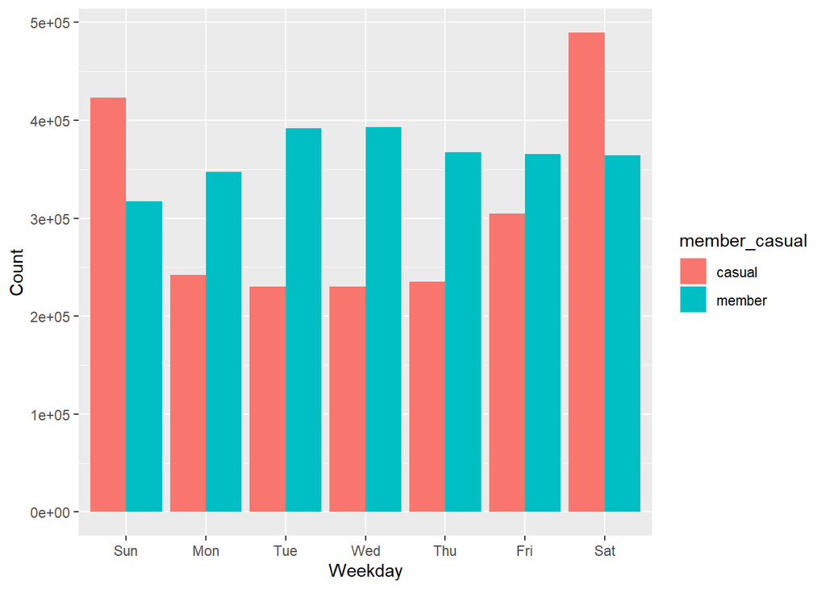

```r
ggplot(Weekly_ride_data)+(mapping = aes(x=Weekday,y=Count,fill = member_casual))+geom_col(position = "dodge")+
 scale_y_continuous()
```

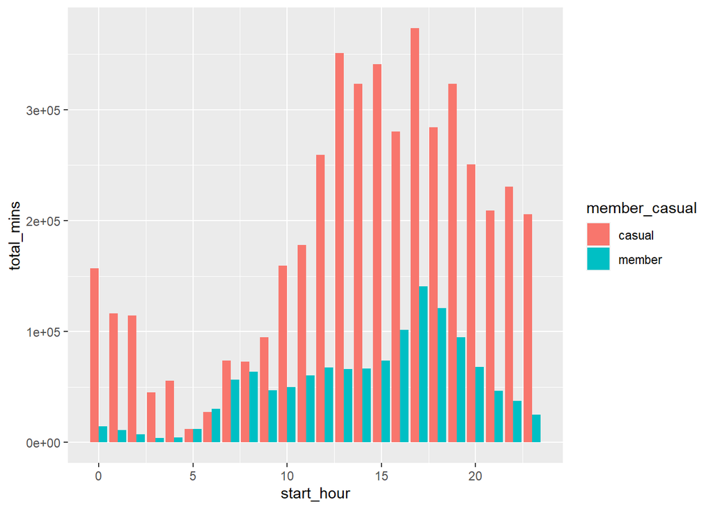

```r
ggplot(hourly_ride_data)+(mapping = aes(x=start_hour,y=total_mins,fill = member_casual))+geom_col(position = "dodge")+ scale_y_continuous()
```

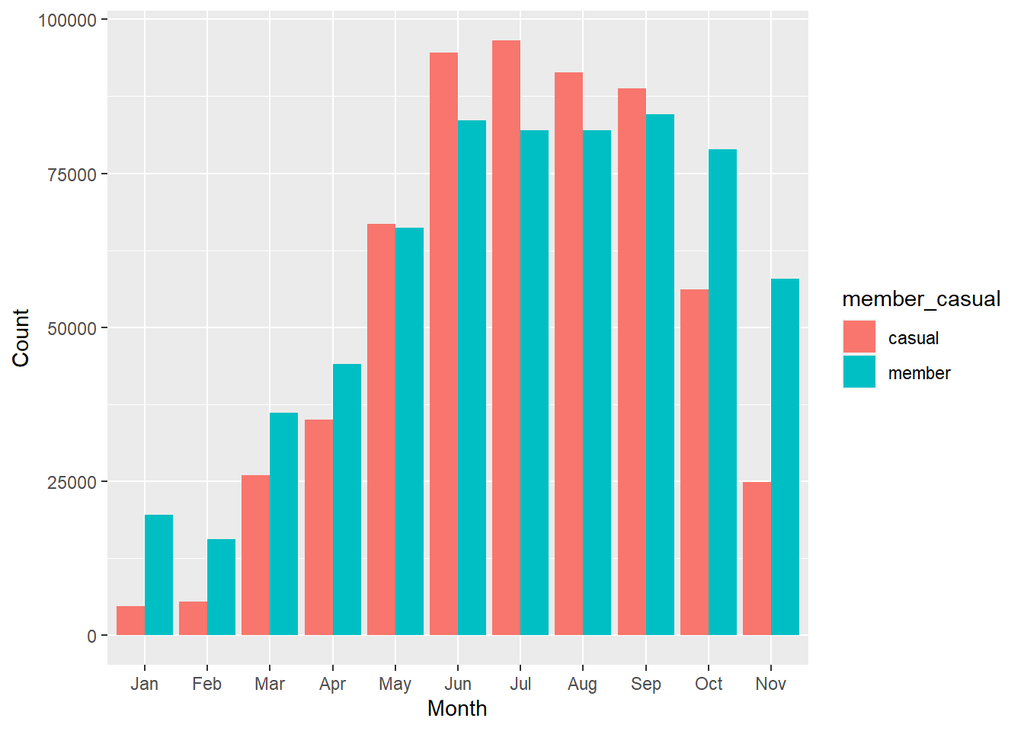

```r
ggplot(monthly_ride_data)+(mapping = aes(x=Month,y=Count,fill=member_casual))+geom_col(position = "dodge")+
  scale_y_continuous()
```

## Insughts we made through our analysis

- Number of rides taken by member type customers are pretty consistent ones, whereas casual type customers tend to rent higher number of bikes during weekends.
- During the whole day people tend to get most active after noon that is after 12:00 pm and that activity keeps high till evening 8:00 of casual customer type.
- We also observed that these bike hiring numbers also get drastically affected with season change, like cold sesaon see very less activity of hiring while warm typically May-Oct seems pretty active, and this observation holds true for both the customer type.

## Thoughts through analysis for further increasing adoptance

- Offering some special type of discounts on membership on weekends might attract more casual customer types to get a membership.
- Daily active as we noticed 12:00 pm - 8:00 pm can be utilized to promote any type of new offers and since these hours are pretty active so maintaining the availablity and any other related stuff will also leave a good impression thus attracting more customers.
- Cutting of some rates or providing some type of offers during cold season might attract people during such times too